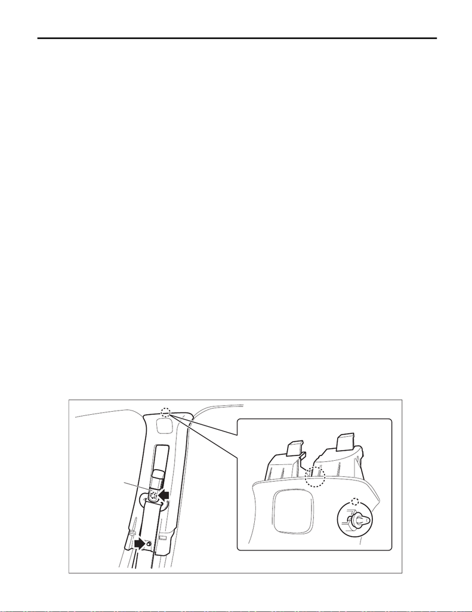

SB-16

Front Seat Belt

SEAT BELT SYSTEM

5. Front Seat Belt

A: REMOVAL

1. SEAT BELT OUTER - FRONT

CAUTION:

• The airbag system (including pretensioner) is fitted with a backup power supply. After disconnect-

ing the battery ground cable, the airbag may operate if you do not wait for 60 seconds or more before

starting the service of airbag system.

• Airbag system satellite safing sensor is located in the lower of the rear seat cushion center. Before

removing the rear seat, refer to “CAUTION” of “General Description” in “AIRBAG SYSTEM” section.

<Ref. to AB-9, CAUTION, General Description.>

• Do not drop or subject the pretensioner to any impact.

• Since the pretensioner and bracket are integrated as a unit, do not disassemble them.

1) Turn the ignition switch to OFF.

2) Disconnect the ground cable from battery and wait for at least 60 seconds before starting work. <Ref. to

NT-5, BATTERY, NOTE, Note.>

NOTE:

• For models other than STI model, disconnect the ground terminal from battery sensor.

• For model with the power seat, move the seat to the front-most position before removing the battery

ground terminal.

3) Tilt the front seat backrest assembly forward, and move the front seat all the way forward.

CAUTION:

For the power seat, move the seat, disconnect the battery ground cable, and then wait for 60 seconds

or more before starting work.

4) Remove the rear seat cushion assembly. <Ref. to SE-29, REMOVAL, Rear Seat.>

5) Remove the cover side sill - front INN, cover side sill - rear INN, and trim panel - center pillar LWR. (On the

side where seat belt assembly is removed) <Ref. to EI-81, REMOVAL, Lower Inner Trim.>

6) Remove the trim panel - center pillar UPR. (On the side where seat belt assembly is removed)

(1) Remove the cover through (a), and remove the seat belt anchor bolt.

(2) Remove the bolt on the lower side of the trim panel - center pillar UPR.

(3) Remove the clip by pulling the upper part of the trim toward you, and while lowering the entire trim, re-

move the trim panel - center pillar UPR.

CAUTION:

Do not reuse the upper clips of the trim panel - center pillar UPR. Once the clip is removed, its holding

force is reduced. Be sure to replace it with a new clip.

EI-03454

(a)

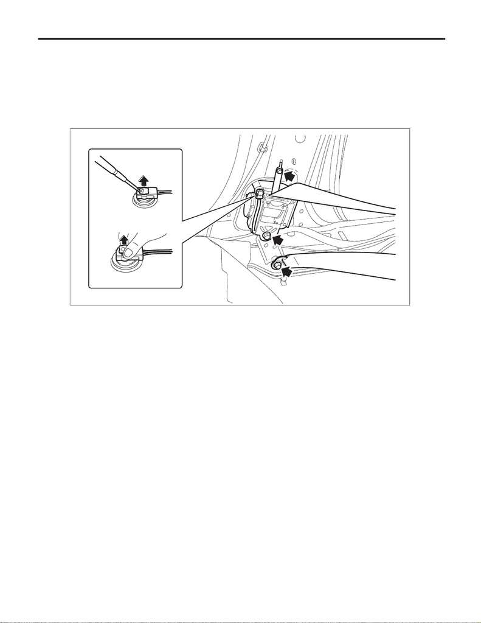

SB-17

Front Seat Belt

SEAT BELT SYSTEM

7) Remove the seat belt outer - front.

(1) Turn over the floor mat to disconnect the belt tension sensor connector. <Ref. to AB-19, DRIVER’S

AIRBAG MODULE, CURTAIN AIRBAG MODULE & PRETENSIONER, PROCEDURE, Airbag Connec-

tor.>

NOTE:

Also disconnect the connector of the passenger’s lap seat belt pretensioner.

(2) Remove the bolt to remove the seat belt retractor.

(3) Remove the lower anchor bolt, and remove the seat belt outer - front.

2. SEAT BELT INNER - FRONT

CAUTION:

The airbag system is fitted with a backup power supply. After disconnecting the battery ground ca-

ble, the airbag may operate if you do not wait for 60 seconds before starting the service of airbag sys-

tem.

1) Turn the ignition switch to OFF.

2) Disconnect the ground cable from battery and wait for at least 60 seconds before starting work. <Ref. to

NT-5, BATTERY, NOTE, Note.>

NOTE:

• For models other than STI model, disconnect the ground terminal from battery sensor.

• For model with the power seat, move the seat to the front-most position before removing the battery

ground terminal.

3) Remove the front seats. <Ref. to SE-9, REMOVAL, Front Seat.>

SB-00617

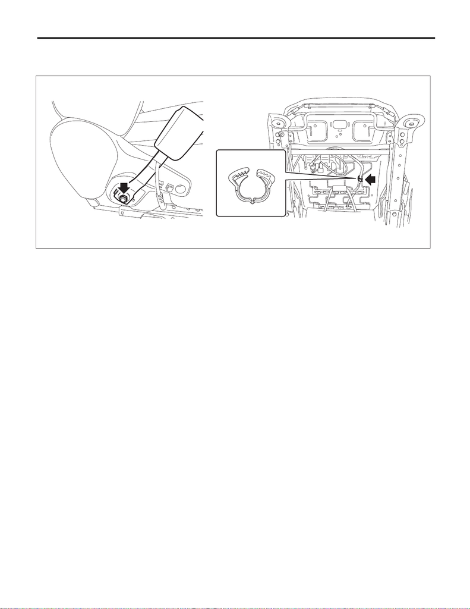

SB-18

Front Seat Belt

SEAT BELT SYSTEM

4) Remove the seat belt inner - front.

(1) Remove the nut, and remove the seat belt inner - front.

(2) Remove the clip for the inner seat belt harness located under the seat cushion.

3. ADJUSTER ASSEMBLY - SEAT BELT

CAUTION:

• The airbag system (including pretensioner) is fitted with a backup power supply. After disconnect-

ing the battery ground cable, the airbag may operate if you do not wait for 60 seconds or more before

starting the service of airbag system.

• Airbag system satellite safing sensor is located in the lower of the rear seat cushion center. Before

removing the rear seat, refer to “CAUTION” of “General Description” in “AIRBAG SYSTEM” section.

<Ref. to AB-9, CAUTION, General Description.>

• Do not drop or subject the pretensioner to any impact.

• Since the pretensioner and bracket are integrated as a unit, do not disassemble them.

1) Turn the ignition switch to OFF.

2) Disconnect the ground cable from battery and wait for at least 60 seconds before starting work. <Ref. to

NT-5, BATTERY, NOTE, Note.>

NOTE:

• For models other than STI model, disconnect the ground terminal from battery sensor.

• For model with the power seat, move the seat to the front-most position before removing the battery

ground terminal.

3) Tilt the backrest assembly forward and move the front seat to the front most position.

CAUTION:

For the power seat, move the seat, disconnect the battery ground cable, and then wait for 60 seconds

or more before starting work.

4) Remove the rear seat cushion assembly. <Ref. to SE-29, REMOVAL, Rear Seat.>

5) Remove the cover side sill - front INN, cover side sill - rear INN, and trim panel - center pillar LWR. <Ref.

to EI-81, REMOVAL, Lower Inner Trim.>

SE-01298

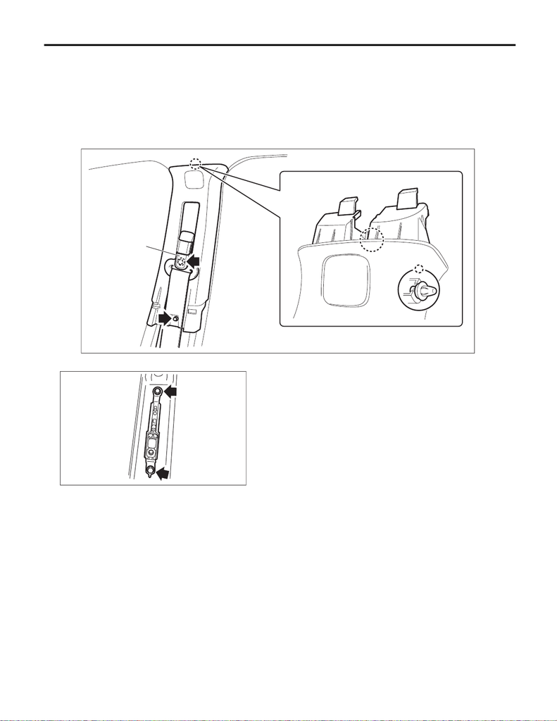

SB-19

Front Seat Belt

SEAT BELT SYSTEM

6) Remove the trim panel - center pillar UPR.

(1) Remove the cover through (a), and remove the seat belt anchor bolt.

(2) Remove the bolt on the lower side of the trim panel - center pillar UPR.

(3) Remove the clip by pulling the upper part of the trim toward you, and while lowering the entire trim, re-

move the trim panel - center pillar UPR.

CAUTION:

Do not reuse the upper clips of the trim panel - center pillar UPR. Once the clip is removed, its holding

force is reduced. Be sure to replace it with a new clip.

7) Remove the bolts, and then remove the adjuster assembly - seat belt.

B: INSTALLATION

1. SEAT BELT OUTER - FRONT

CAUTION:

• The parts of the driver and passenger sides are not the same. Before installation, make sure that

the correct part is used.

• During installation, make sure that the seat belts are not twisted.

• After installation, make sure that the seat belt can be pulled out and retracted smoothly.

• Make sure that the seat belt harness is not caught anywhere. Wrong harness rooting may cause

the harness short from pinch.

• Do not reuse the upper clips of the trim panel - center pillar UPR. Once the clip is removed, its hold-

ing force is reduced. Be sure to replace it with a new clip.

1) Before installation, perform a unit inspection of retractor. <Ref. to SB-22, INSPECTION, Front Seat Belt.>

2) Install the seat belt outer - front.

Tightening torque:

Front seat belt: <Ref. to SB-2, FRONT SEAT BELT, COMPONENT, General Description.>

EI-03454

(a)

SB-00352

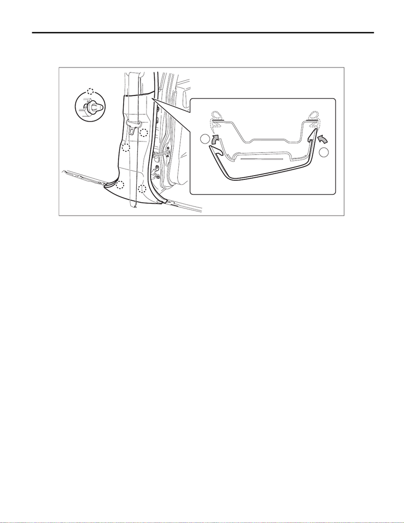

SB-20

Front Seat Belt

SEAT BELT SYSTEM

NOTE:

Assemble the trim panel - center pillar LWR to the trim panel - center pillar UPR securely.

Tightening torque:

Trim panel - center pillar UPR: 7.5 N·m (0.8 kgf-m, 5.5 ft-lb)

4) Install the trim panel - center pillar LWR.

5) Install the trim panel - center pillar LWR, cover side sill - front INN, and cover side sill - rear INN.

6) Install the rear seat cushion assembly.

7) Connect the battery ground terminal. <Ref. to NT-5, BATTERY, NOTE, Note.>

NOTE:

For models other than STI model, connect the ground terminal to battery sensor.

8) After installation, check the following points.

• The seat belt is not twisted.

• The seat belt can be pulled out and retracted smoothly.

• The adjuster assembly - seat belt can be moved smoothly.

• Check that the airbag warning light lights up for approximately 6 seconds and then turns off when connect-

ing the battery ground cable and turning the ignition switch to ON.

2. SEAT BELT INNER - FRONT

CAUTION:

• Before installation, make sure that the correct part is used.

• During installation, make sure that the seat belts are not twisted.

• Check that there is no pinching of the seat belt harness. Wrong harness rooting may cause the har-

ness short from pinch.

• Do not forget the wave washer, when installing front seat inner belt assembly.

1) Install the seat belt inner - front.

Tightening torque:

53 N·m (5.4 kgf-m, 39.1 ft-lb)

EI-03453

1

2

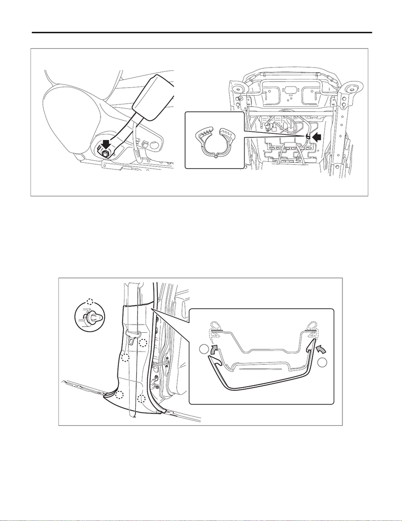

SB-21

Front Seat Belt

SEAT BELT SYSTEM

2) Locate the seat belt harness and retain it with a harness clip.

3) Install the seat assembly to the body. <Ref. to SE-10, INSTALLATION, Front Seat.>

4) Connect the battery ground terminal. <Ref. to NT-5, BATTERY, NOTE, Note.>

NOTE:

For models other than STI model, connect the ground terminal to battery sensor.

3. ADJUSTABLE ANCHOR ASSY

NOTE:

Assemble the trim panel - center pillar LWR to the trim panel - center pillar UPR securely.

Tightening torque:

Trim panel - center pillar UPR: 7.5 N·m (0.8 kgf-m, 5.5 ft-lb)

2) Install the trim panel - center pillar LWR.

3) Install the trim panel - center pillar LWR, cover side sill - front INN, and cover side sill - rear INN.

4) Install the rear seat cushion assembly.

SE-01298

EI-03453

1

2

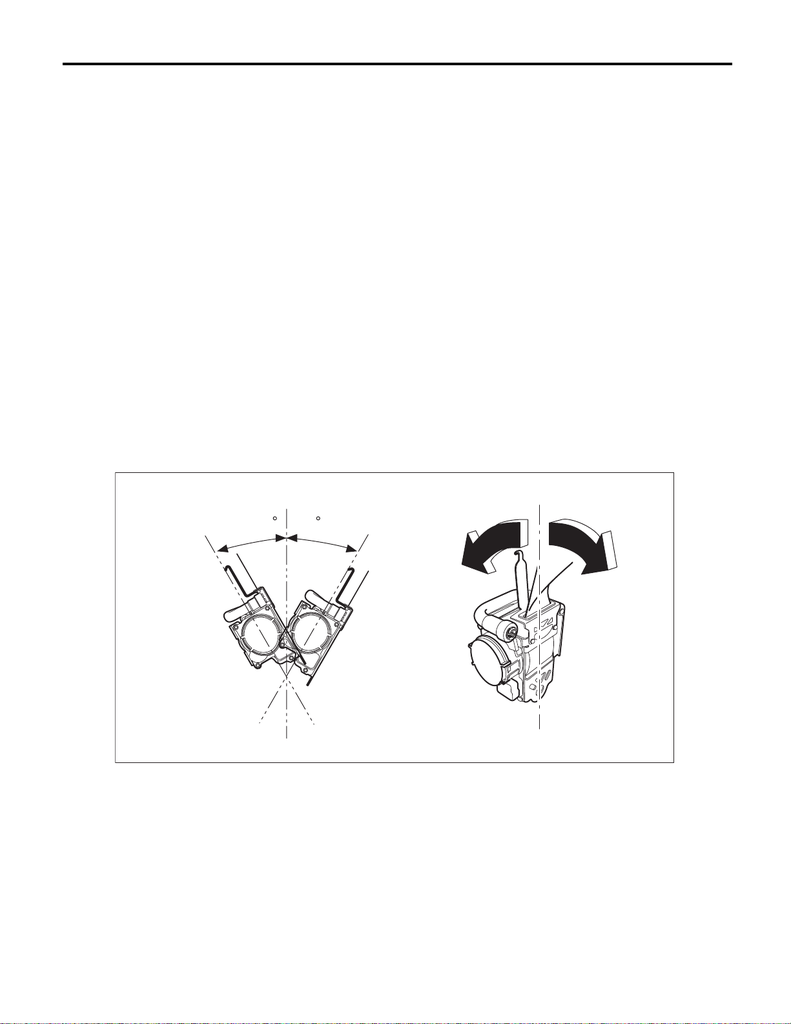

SB-22

Front Seat Belt

SEAT BELT SYSTEM

5) Connect the battery ground terminal. <Ref. to NT-5, BATTERY, NOTE, Note.>

NOTE:

For models other than STI model, connect the ground terminal to battery sensor.

6) After installation, check the following points.

• The seat belt is not twisted.

• The seat belt can be pulled out and retracted smoothly.

• The adjuster assembly - seat belt can be moved smoothly.

• Check that the airbag warning light lights up for approximately 6 seconds and then turns off when connect-

ing the battery ground cable and turning the ignition switch to ON.

C: INSPECTION

1. VISUAL INSPECTION

Check for the following, and replace with new parts if necessary.

• Pretensioner is cracked or deformed.

• Adjuster assembly - seat belt is cracked or deformed.

• Seat belt is slackened, bent or worn.

• Seat belt is abnormally wound or extended.

• Seat belt inner - front is deformed or damaged.

• Seat belt buckle cannot be engaged properly.

2. ELR LOCK MECHANISM INSPECTION

1) Hold the retractor upright (as installed in the vehicle) and check the ELR lock mechanism.

2) Tilt the retractor from the upright posture and check the following points.

• It does not lock if the inclination angle is 15° or less.

SB-00606

15

15

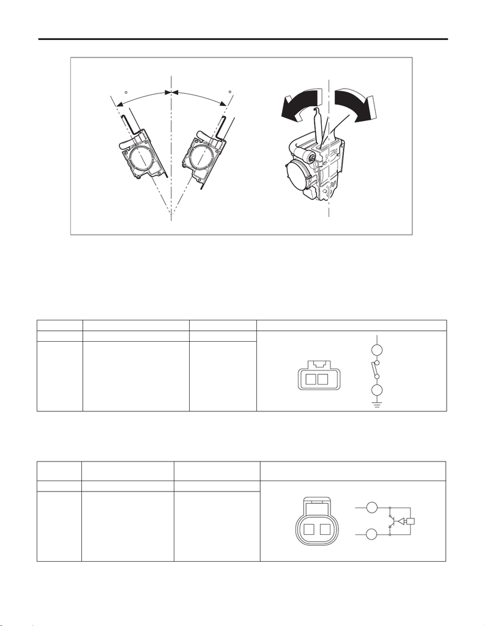

SB-23

Front Seat Belt

SEAT BELT SYSTEM

• It remains locked if the inclination angle is 27° or more.

3) If the ELR lock mechanism does not operate properly, replace the seat belt outer - front with a new part.

3. SEAT BELT SWITCH INSPECTION

Preparation tool:

Circuit tester

• Driver’s seat

Measure the resistance between the terminals when the seat belt inner - front is in each of the following op-

eration conditions.

Replace the seat belt inner - front if the inspection result is not within the standard.

• Passenger’s seat

Measure the current value between the terminals when the seat belt inner - front is in each of the following

operation conditions.

Replace the seat belt inner - front if the inspection result is not within the standard.

Terminal No. Inspection conditions Standard Circuit

2 — 1 Tongue plate inserted 1 MΩ or more

2 — 1 Tongue plate detached 1 Ω or less

Terminal

No.

Inspection conditions Standard Circuit

1 — 2 Tongue plate inserted 12 — 18 mA

1 — 2 Tongue plate detached 4 — 7 mA

SB-00607

27

27

SB-00481

2

1

21

SB-00482

12

1

2